# MR (field) and the studentized complement field on the continuous/MD path — campaign mdsgnb20 (effMaxSG, ε = 0.20), four cells, paired with mdf1

- Show All Code
- Hide All Code
- View Source

Cross-cell summary of the committed combined bundles: Ĥ and Ĥᶜ tables, the D3 bound-location ladder, the joint pair, the rule contrast with mdf1, regime diagnostics, display; writes md_field_metrics.csv

Author

Larry F. León

Published

September 16, 2026

Transplant of `summary_continuous_field_mdf1.qmd` (TASK_md_field_rerun_2026-09-15 §3.1); every metric definition below is that document’s (its line is cited in the code). Self-contained: reads the campaign’s four combined bundles (`mr_md_harm/*_nb20_mdsgnb20_d5000/*_combined_1_2000.rds`) and `mdf1`’s four for the paired sections. Every estimator column is **oriented** (positive = harm; the gate works on $-\,$`cd4_change`); `betaHhat_*` are raw and are oriented here with $-1$. Bounds are read by **location** against the D3 ladder τ = 0, 10, 20, 30, 40, 60, 80, 100 (CD4 cells/mm³, harm-oriented): on $\hat H$ the one-sided 95% lower bound ≥ τ reads “harm of at least τ supported”; on $\hat H^{c}$ the one-sided 95% upper bound ≤ τ reads “harm of at most τ supported”. Coverage carries Wilson 95% intervals and Monte Carlo SEs; bias is in MD units and in SD units. **The null cell** has no subgroup: a homogeneous +26 on the harm-oriented scale is the target of every $\hat H$ and $\hat H^{c}$ there, and its declaration rate stands beside it in every table. Excluded everywhere: IJ winner-only / winner-floor, κ variants, `field_uniform`; FB was off in this campaign (no FB rows).

```r
suppressPackageStartupMessages({ library(forestsearch); library(ggplot2); library(knitr) })
tag <- Sys.getenv("MDSG_SUMMARY_TAG", "mdsgnb20"); ref_tag <- "mdf1"
glob_new <- Sys.getenv("MDSG_SUMMARY_GLOB", "combined_1_2000")     # dry run on a smoke batch: "res_1_20"
out_dir  <- Sys.getenv("MDSG_SUMMARY_OUT", ".")
null_lab <- "null n500 (no subgroup; homogeneous +26)"
cells <- list(list(lab = "md40 n500",  md = "40",  n = 500L), list(lab = "md120 n500", md = "120", n = 500L),
              list(lab = null_lab,     md = "null", n = 500L), list(lab = "md40 n700",  md = "40",  n = 700L))
mdtok <- function(cl) if (cl$md == "null") "mdnull" else sprintf("md%s", cl$md)
stem_new <- function(cl) sprintf("fs_effMaxSG_mr_field_%s_knoise0_n%d_nb20_%s", mdtok(cl), cl$n, tag)
stem_ref <- function(cl) sprintf("fs_maxeffCons_mr_field_%s_knoise0_n%d_%s", mdtok(cl), cl$n, ref_tag)
path_of <- function(s, glob) { f <- Sys.glob(file.path("mr_md_harm", paste0(s, "_d5000"), paste0(s, "_", glob, ".rds"))); if (length(f)) f[1] else NA_character_ }
commit_of <- function(p) { x <- suppressWarnings(system2("git", c("log", "--diff-filter=A", "-1", "--format=%h", "--", shQuote(p)), stdout = TRUE, stderr = FALSE)); if (length(x) && nzchar(x[1])) x[1] else "untracked" }
z95 <- qnorm(0.95)
# mdf1 summary :38-41 (Wilson, formatting, finite mean / sd)
wilson <- function(x, n, z = qnorm(0.975)) { if (!is.finite(x) || n <= 0) return(c(NA, NA)); ctr <- (x + z^2/(2*n))/(1 + z^2/n); hw <- z*sqrt(x*(1-x)/n + z^2/(4*n^2))/(1 + z^2/n); c(ctr - hw, ctr + hw) }
fmtw <- function(x, n) { w <- wilson(x, n); sprintf("%.3f (%.3f, %.3f)", x, w[1], w[2]) }
mfin <- function(x) { x <- x[is.finite(x)]; if (length(x)) mean(x) else NA_real_ }
sdfin <- function(x) { x <- x[is.finite(x)]; if (length(x) > 1) sd(x) else NA_real_ }
pse <- function(p, n) if (is.finite(p) && n > 0) sqrt(p * (1 - p) / n) else NA_real_   # task §3.2: proportions
tau_H <- c(0, 10, 20, 30, 40, 60, 80, 100); tau_Hc <- tau_H                            # D3 ladder
EX <- list()   # extract rows (task §3.2)
ex <- function(cell, block, estimator, metric, value, mc_se = NA_real_, n = NA_integer_, tau = NA_real_, wl = NA_real_, wh = NA_real_, commit = NA_character_, campaign = tag)
  EX[[length(EX) + 1]] <<- data.frame(campaign = campaign, cell = cell, block = block, estimator = estimator, metric = metric, tau = tau,
                                      value = value, mc_se = mc_se, wilson_lo = wl, wilson_hi = wh, n = n, commit = commit, stringsAsFactors = FALSE)
exp_ <- function(cell, block, estimator, metric, p, n, tau = NA_real_, commit, campaign = tag) { w <- wilson(p, n); ex(cell, block, estimator, metric, p, pse(p, n), n, tau, w[1], w[2], commit, campaign) }

rows <- list(); bl <- list(); jt <- list(); rc <- list(); rg <- list(); disp <- list(); status <- list(); decl <- list()
for (cl in cells) {
  p <- path_of(stem_new(cl), glob_new); pr <- path_of(stem_ref(cl), "combined_1_2000")
  if (is.na(p)) { status[[cl$lab]] <- "NOT RUN"; next }
  cm <- commit_of(p)
  b <- readRDS(p); r <- r0 <- b$results; rr <- readRDS(pr)$results; rr <- rr[match(r$sim_id, rr$sim_id), ]
  or <- -1
  det <- r$detected %in% 1L; d <- r[det, ]; d$bH <- or * d$betaHhat_H; d$bHc <- or * d$betaHhat_Hc
  status[[cl$lab]] <- sprintf("%d reps, %d declared (%.4f), pkg %s, host %s, commit %s", nrow(r), nrow(d), mean(det), b$meta$pkg_version, b$meta$hostname, cm)
  decl[[cl$lab]] <- data.frame(cell = cl$lab, replicates = nrow(r), declared = nrow(d), rate = mean(det), mc_se = pse(mean(det), nrow(r)),
                               mdf1_rate = mean(rr$detected %in% 1L), stringsAsFactors = FALSE)
  exp_(cl$lab, "H", "all", "declaration_rate", mean(det), nrow(r), commit = cm)
  cm_ref <- commit_of(pr)
  exp_(cl$lab, "H", "all", "declaration_rate", mean(rr$detected %in% 1L), nrow(rr), commit = cm_ref, campaign = ref_tag)
  struct <- list(H = or * b$truth$effect_Q, Hc = or * b$truth$effect_Qc)
  # ---- Ĥ and Ĥᶜ tables: mdf1 summary :49-66 verbatim in structure; the complement adds field-s (evaluated) beside the unstudentized field (paired)
  for (sfx in c("H", "Hc")) {
    side <- if (sfx == "H") "lower" else "upper"; sgn <- if (side == "lower") -1 else 1
    beta <- d[[if (sfx == "H") "bH" else "bHc"]]
    ests <- list(naive = list(e = d[[paste0("nv_", sfx, "_est")]], lo = d[[paste0("nv_", sfx, "_lo")]], hi = d[[paste0("nv_", sfx, "_hi")]], se = d[[paste0("nv_", sfx, "_se")]]),
                 oracle = list(e = d[[paste0("or_", sfx, "_est")]], lo = d[[paste0("or_", sfx, "_lo")]], hi = d[[paste0("or_", sfx, "_hi")]], se = d[[paste0("or_", sfx, "_se")]]),
                 `MR (IJ)` = list(e = d[[paste0("mr_", sfx, "_est")]], lo = d[[paste0("mr_", sfx, "_lo")]], hi = d[[paste0("mr_", sfx, "_hi")]], se = d[[paste0("mr_", sfx, "_se_ij")]]),
                 `MR (field)` = list(e = d[[paste0("fld_", sfx, "_est2")]], lo = d[[paste0("fld_", sfx, "_lo2s")]], hi = d[[paste0("fld_", sfx, "_hi2s")]], se = d[[paste0("fld_", sfx, "_se")]]))
    if (sfx == "Hc") ests$`MR (field-s)` <- list(e = d$fld_Hc_est2_s, lo = d$fld_Hc_lo2s_s, hi = d$fld_Hc_hi2s_s, se = d$fld_Hc_se_s)
    code <- c(naive = "naive", oracle = "oracle", `MR (IJ)` = "mr", `MR (field)` = "fld", `MR (field-s)` = "fld_s")
    for (k in names(ests)) {
      ec <- ests[[k]]; e <- ec$e; se <- ec$se
      tgt <- if (k == "oracle") rep(struct[[sfx]], length(e)) else beta                       # :58
      ctr <- if (k %in% c("MR (field)", "MR (field-s)")) d[[paste0("mr_", sfx, "_est")]] else e   # :59
      b1 <- if (k == "MR (field)") d[[paste0("fld_", sfx, if (side == "upper") "_up1s" else "_lo1s")]]
            else if (k == "MR (field-s)") d$fld_Hc_up1s_s else e + sgn * z95 * se                # :60
      ok <- is.finite(e) & is.finite(tgt); ok2 <- ok & is.finite(ec$lo) & is.finite(ec$hi); ok1 <- ok & is.finite(b1)
      n <- sum(ok); bias <- mean(e[ok] - tgt[ok]); sde <- sdfin(e); sem <- mfin(se)             # :62
      c2 <- mean(tgt[ok2] >= ec$lo[ok2] & tgt[ok2] <= ec$hi[ok2]); c1 <- if (side == "lower") mean(tgt[ok1] >= b1[ok1]) else mean(tgt[ok1] <= b1[ok1])   # :63
      # Monte Carlo SEs (task §3.2): bias SD/sqrt(n); SD SD/sqrt(2(n-1)); mean SE SD(SE)/sqrt(n); SE/SD delta method
      bias_se <- sd(e[ok] - tgt[ok]) / sqrt(n); sd_se <- sde / sqrt(2 * (n - 1)); sem_se <- sdfin(se) / sqrt(sum(is.finite(se)))
      ratio <- sem / sde; ratio_se <- ratio * sqrt((sem_se / sem)^2 + (sd_se / sde)^2)
      rows[[length(rows) + 1]] <- data.frame(cell = cl$lab, block = sfx, estimator = k, n = n, decl = mean(det), bias = bias, bias_sd = bias / sde, SD = sde, SE = sem, SE_SD = ratio,
                                             cov1 = c1, cov1_w = fmtw(c1, sum(ok1)), cov2 = c2, cov2_w = fmtw(c2, sum(ok2)), side = side,
                                             halfwidth = mfin((ec$hi - ec$lo) / 2), margin1 = mfin(sgn * (b1 - ctr)), stringsAsFactors = FALSE)
      kc <- code[[k]]
      ex(cl$lab, sfx, kc, "bias_md", bias, bias_se, n, commit = cm); ex(cl$lab, sfx, kc, "bias_sd_units", bias / sde, bias_se / sde, n, commit = cm)
      ex(cl$lab, sfx, kc, "sd_emp", sde, sd_se, n, commit = cm); ex(cl$lab, sfx, kc, "se_mean", sem, sem_se, n, commit = cm)
      ex(cl$lab, sfx, kc, "se_over_sd", ratio, ratio_se, n, commit = cm)
      exp_(cl$lab, sfx, kc, if (side == "lower") "cov1_lower" else "cov1_upper", c1, sum(ok1), commit = cm); exp_(cl$lab, sfx, kc, "cov2", c2, sum(ok2), commit = cm)
      ex(cl$lab, sfx, kc, "halfwidth_md", mfin((ec$hi - ec$lo) / 2), n = n, commit = cm); ex(cl$lab, sfx, kc, "margin1_md", mfin(sgn * (b1 - ctr)), n = n, commit = cm)
    }
    # ---- D3 bound-location ladder: field | oracle on Ĥ, field-s | oracle on Ĥᶜ (mdf1 summary :68-72, ladder per D3, oracle beside, MC SEs)
    lad <- if (sfx == "H") list(`MR (field)` = d$fld_H_lo1s, oracle = d$or_H_est - z95 * d$or_H_se, `MR (IJ)` = d$mr_H_est - z95 * d$mr_H_se_ij, naive = d$nv_H_est - z95 * d$nv_H_se)
           else list(`MR (field-s)` = d$fld_Hc_up1s_s, oracle = d$or_Hc_est + z95 * d$or_Hc_se, `MR (field)` = d$fld_Hc_up1s, `MR (IJ)` = d$mr_Hc_est + z95 * d$mr_Hc_se_ij, naive = d$nv_Hc_est + z95 * d$nv_Hc_se)
    tau <- if (sfx == "H") tau_H else tau_Hc
    for (k in names(lad)) {
      bb <- lad[[k]]; bb <- bb[is.finite(bb)]
      if (!length(bb)) {   # the null cell's harm oracle: Q is empty, no bound exists; carry the ladder columns as NA so the rows bind
        row <- data.frame(cell = cl$lab, block = sfx, estimator = k, n = 0L, mean = NA_real_, q05 = NA_real_, q25 = NA_real_, median = NA_real_, q75 = NA_real_, q95 = NA_real_, stringsAsFactors = FALSE)
        for (i in seq_along(tau)) row[[sprintf(if (side == "lower") "P(L>=%g)" else "P(U<=%g)", tau[i])]] <- NA_character_
        bl[[length(bl) + 1]] <- row; next }
      sh <- vapply(tau, function(t) if (side == "lower") mean(bb >= t) else mean(bb <= t), numeric(1))
      qs <- quantile(bb, c(.05, .25, .5, .75, .95), names = FALSE)
      row <- data.frame(cell = cl$lab, block = sfx, estimator = k, n = length(bb), mean = mean(bb), q05 = qs[1], q25 = qs[2], median = qs[3], q75 = qs[4], q95 = qs[5], stringsAsFactors = FALSE)
      for (i in seq_along(tau)) { row[[sprintf(if (side == "lower") "P(L>=%g)" else "P(U<=%g)", tau[i])]] <- sprintf("%.3f (%.3f)", sh[i], pse(sh[i], length(bb)))
        exp_(cl$lab, sfx, code[[k]], if (side == "lower") "share_lower_ge_tau" else "share_upper_le_tau", sh[i], length(bb), tau[i], commit = cm) }
      ex(cl$lab, sfx, code[[k]], "bound_mean", mean(bb), sd(bb) / sqrt(length(bb)), length(bb), commit = cm)
      for (q in c(.05, .25, .5, .75, .95)) ex(cl$lab, sfx, code[[k]], sprintf("bound_q%02d", round(100 * q)), quantile(bb, q, names = FALSE), n = length(bb), commit = cm)
      bl[[length(bl) + 1]] <- row
    }
  }
  # ---- joint pair (mdf1 summary :77-80): the field-s Bonferroni pair evaluated; the unstudentized pair beside; calibrated split as diagnostics
  both_s <- is.finite(d$fld_joint_s_bonf_loH) & is.finite(d$fld_joint_s_bonf_upHc) & is.finite(d$bH) & is.finite(d$bHc)
  both_u <- is.finite(d$fld_joint_bonf_loH) & is.finite(d$fld_joint_bonf_upHc) & is.finite(d$bH) & is.finite(d$bHc)
  pairs <- list(`Bonferroni field-s (gamma = 0.025)` = list(lo = d$fld_joint_s_bonf_loH, up = d$fld_joint_s_bonf_upHc, ok = both_s, code = "bonf_s"),
                `Bonferroni unstudentized (gamma = 0.025)` = list(lo = d$fld_joint_bonf_loH, up = d$fld_joint_bonf_upHc, ok = both_u, code = "bonf"),
                `separate 95% bounds: field lower, field-s upper` = list(lo = d$fld_H_lo1s, up = d$fld_Hc_up1s_s, ok = both_s, code = "separate_s"))
  for (nm in names(pairs)) { pp <- pairs[[nm]]; ok <- pp$ok; cH <- d$bH[ok] >= pp$lo[ok]; cC <- d$bHc[ok] <= pp$up[ok]; jc <- mean(cH & cC)
    jt[[length(jt) + 1]] <- data.frame(cell = cl$lab, pair = nm, declared = nrow(d), both_bounds = sum(ok), share_both = sum(ok) / nrow(d), joint = fmtw(jc, sum(ok)), joint_mc_se = pse(jc, sum(ok)),
                                       cov_H = mean(cH), cov_Hc = mean(cC), margin_H = mean(d$mr_H_est[ok] - pp$lo[ok]), margin_Hc = mean(pp$up[ok] - d$mr_Hc_est[ok]), stringsAsFactors = FALSE)
    exp_(cl$lab, "joint", pp$code, "joint_coverage", jc, sum(ok), commit = cm); exp_(cl$lab, "joint", pp$code, "share_both_bounds", sum(ok) / nrow(d), nrow(d), commit = cm)
    exp_(cl$lab, "joint", pp$code, "cov_H", mean(cH), sum(ok), commit = cm); exp_(cl$lab, "joint", pp$code, "cov_Hc", mean(cC), sum(ok), commit = cm)
    ex(cl$lab, "joint", pp$code, "margin_H_md", mean(d$mr_H_est[ok] - pp$lo[ok]), sd(d$mr_H_est[ok] - pp$lo[ok]) / sqrt(sum(ok)), sum(ok), commit = cm)
    ex(cl$lab, "joint", pp$code, "margin_Hc_md", mean(pp$up[ok] - d$mr_Hc_est[ok]), sd(pp$up[ok] - d$mr_Hc_est[ok]) / sqrt(sum(ok)), sum(ok), commit = cm) }
  for (v in list(c("gamma_mean_s", "fld_joint_s_gamma"), c("corr_s", "fld_joint_s_corr"), c("gamma_mean", "fld_joint_gamma"), c("corr", "fld_joint_corr")))
    ex(cl$lab, "joint", "calibrated", v[1], mfin(d[[v[2]]]), sdfin(d[[v[2]]]) / sqrt(sum(is.finite(d[[v[2]]]))), sum(is.finite(d[[v[2]]])), commit = cm)
```

```r
  # ---- rule contrast with mdf1, paired by sim_id (task §3.1): n_sel / n_harm / n_true as the recorder defines them
  #   template :637  rec$n_true <- sum(df[[harm_col]] == 1L)
  #   template :692  rec$n_harm <- sum(sgv == 1L, na.rm = TRUE)     (sgv = fs.est$grp.consistency$sg.harm.id, the analysis-sample membership)
  #   template :693  rec[c("sens","spec","ppv","npv")] <- as.list(.classify(sgv, df[[harm_col]]))   (.classify :484-493: sens = tp/(tp+fn), NA when tp+fn = 0; ppv = tp/(tp+fp))
  #   template :700  rec$n_sel <- g$n_selected                      (the gate's count of the selected family member)
  dr <- rr[det, ]; dd <- d$n_harm - dr$n_harm
  crow <- function(lab, x, xr) data.frame(cell = cl$lab, quantity = lab, effMaxSG = x, maxeffCons_mdf1 = xr, stringsAsFactors = FALSE)
  o1 <- function(x, sfx, side, tgt) { b1 <- x[[paste0("fld_", sfx, if (side == "lower") "_lo1s" else "_up1s")]]; ok <- is.finite(b1) & is.finite(tgt); if (side == "lower") mean(tgt[ok] >= b1[ok]) else mean(tgt[ok] <= b1[ok]) }
  rrbH <- or * dr$betaHhat_H; rrbHc <- or * dr$betaHhat_Hc
  cs1 <- o1(d, "H", "lower", d$bH); cs1r <- o1(dr, "H", "lower", rrbH); cs2 <- o1(d, "Hc", "upper", d$bHc); cs2r <- o1(dr, "Hc", "upper", rrbHc)
  oks <- is.finite(d$fld_Hc_up1s_s) & is.finite(d$bHc); cs3 <- mean(d$bHc[oks] <= d$fld_Hc_up1s_s[oks])
  rc[[length(rc) + 1]] <- rbind(
    crow("declared replicates", nrow(d), nrow(dr)),
    crow("mean |Hhat| (n_harm)", mean(d$n_harm, na.rm = TRUE), mean(dr$n_harm, na.rm = TRUE)),
    crow("mean n_sel (gate)", mean(d$n_sel, na.rm = TRUE), mean(dr$n_sel, na.rm = TRUE)),
    crow("sensitivity (mean over declared; NA where n_true = 0)", mfin(d$sens), mfin(dr$sens)),
    crow("PPV (mean over declared)", mfin(d$ppv), mfin(dr$ppv)),
    crow("|Hhat| grew / stayed / shrank vs mdf1 (paired by sim_id)", sprintf("%d / %d / %d", sum(dd > 0, na.rm = TRUE), sum(dd == 0, na.rm = TRUE), sum(dd < 0, na.rm = TRUE)), "-"),
    crow("field one-sided lower coverage on beta(Hhat)", cs1, cs1r),
    crow("unstudentized field one-sided upper coverage on beta(Hhat^c)", cs2, cs2r),
    crow("field-s one-sided upper coverage on beta(Hhat^c)", cs3, NA))
  ex(cl$lab, "H", "all", "mean_n_harm", mean(d$n_harm, na.rm = TRUE), sdfin(d$n_harm) / sqrt(sum(is.finite(d$n_harm))), sum(is.finite(d$n_harm)), commit = cm)
  ex(cl$lab, "H", "all", "mean_n_sel", mean(d$n_sel, na.rm = TRUE), sdfin(d$n_sel) / sqrt(sum(is.finite(d$n_sel))), sum(is.finite(d$n_sel)), commit = cm)
  ex(cl$lab, "H", "all", "sensitivity_mean", mfin(d$sens), sdfin(d$sens) / sqrt(sum(is.finite(d$sens))), sum(is.finite(d$sens)), commit = cm)
  ex(cl$lab, "H", "all", "ppv_mean", mfin(d$ppv), sdfin(d$ppv) / sqrt(sum(is.finite(d$ppv))), sum(is.finite(d$ppv)), commit = cm)
  for (v in c("grew", "stayed", "shrank")) { cnt <- switch(v, grew = sum(dd > 0, na.rm = TRUE), stayed = sum(dd == 0, na.rm = TRUE), shrank = sum(dd < 0, na.rm = TRUE)); exp_(cl$lab, "H", "all", paste0("share_nharm_", v, "_vs_mdf1"), cnt / sum(is.finite(dd)), sum(is.finite(dd)), commit = cm)
    ex(cl$lab, "H", "all", paste0("count_nharm_", v, "_vs_mdf1"), cnt, n = sum(is.finite(dd)), commit = cm) }
  # the paired mdf1 comparators (campaign = "mdf1"; the same seeds), as the contrast table prints them
  ex(cl$lab, "H", "all", "mean_n_harm", mean(dr$n_harm, na.rm = TRUE), sdfin(dr$n_harm) / sqrt(sum(is.finite(dr$n_harm))), sum(is.finite(dr$n_harm)), commit = cm_ref, campaign = ref_tag)
  ex(cl$lab, "H", "all", "mean_n_sel", mean(dr$n_sel, na.rm = TRUE), sdfin(dr$n_sel) / sqrt(sum(is.finite(dr$n_sel))), sum(is.finite(dr$n_sel)), commit = cm_ref, campaign = ref_tag)
  ex(cl$lab, "H", "all", "sensitivity_mean", mfin(dr$sens), sdfin(dr$sens) / sqrt(sum(is.finite(dr$sens))), sum(is.finite(dr$sens)), commit = cm_ref, campaign = ref_tag)
  ex(cl$lab, "H", "all", "ppv_mean", mfin(dr$ppv), sdfin(dr$ppv) / sqrt(sum(is.finite(dr$ppv))), sum(is.finite(dr$ppv)), commit = cm_ref, campaign = ref_tag)
  exp_(cl$lab, "H", "fld", "cov1_lower", cs1r, sum(is.finite(dr$fld_H_lo1s) & is.finite(rrbH)), commit = cm_ref, campaign = ref_tag)
  exp_(cl$lab, "Hc", "fld", "cov1_upper", cs2r, sum(is.finite(dr$fld_Hc_up1s) & is.finite(rrbHc)), commit = cm_ref, campaign = ref_tag)
  # ---- regime diagnostics (mdf1 summary :82-85)
  nvc <- mfin(d$nv_Hc_se)
  rg[[length(rg) + 1]] <- data.frame(cell = cl$lab, n_det = nrow(d), p_hat_mean = mean(d$p_hat_H, na.rm = TRUE), p_hat_lt05 = mean(d$p_hat_H < 0.5, na.rm = TRUE),
                                     sd_btc_naive = sdfin(d$mr_Hc_est) / nvc, lamc_naive = mfin(d$fld_Hc_se) / nvc, lamc_s_naive = mfin(d$fld_Hc_se_s) / nvc,
                                     ij_sd_H = mfin(d$mr_H_se_ij) / sdfin(d$mr_H_est), ij_sd_Hc = mfin(d$mr_Hc_se_ij) / sdfin(d$mr_Hc_est),
                                     fit_secs = mean(r$fit_mr_secs), field_secs = mfin(d$fld_H_secs), comp_secs = mfin(d$fld_Hc_secs), stringsAsFactors = FALSE)
  ex(cl$lab, "H", "all", "p_hat_mean", mean(d$p_hat_H, na.rm = TRUE), sdfin(d$p_hat_H) / sqrt(sum(is.finite(d$p_hat_H))), sum(is.finite(d$p_hat_H)), commit = cm)
  exp_(cl$lab, "H", "all", "p_hat_share_lt_05", mean(d$p_hat_H < 0.5, na.rm = TRUE), sum(is.finite(d$p_hat_H)), commit = cm)
  ex(cl$lab, "Hc", "mr", "sd_btc_over_naive_se", sdfin(d$mr_Hc_est) / nvc, n = sum(is.finite(d$mr_Hc_est)), commit = cm)
  ex(cl$lab, "Hc", "fld", "lamsd_over_naive_se", mfin(d$fld_Hc_se) / nvc, n = sum(is.finite(d$fld_Hc_se)), commit = cm)
  ex(cl$lab, "Hc", "fld_s", "lamsd_over_naive_se", mfin(d$fld_Hc_se_s) / nvc, n = sum(is.finite(d$fld_Hc_se_s)), commit = cm)
  # ---- display (mdf1 summary :87-90); field-s through a renamed copy (task §3.1, no R/ change)
  ro <- r; ro$betaHhat_H <- or * r$betaHhat_H; ro$betaHhat_Hc <- or * r$betaHhat_Hc
  dh <- fs_sim_bias_coverage(ro, block = "H", estimators = c("naive", "mr", "fld"), scale = "identity"); dh$block <- "H"; dh$cell <- cl$lab
  dc <- fs_sim_bias_coverage(ro, block = "Hc", estimators = c("naive", "mr", "fld"), side = "upper", scale = "identity"); dc$block <- "Hc"; dc$cell <- cl$lab
  rs <- ro; for (s in c("est2","up1s","lo1s","lo2s","hi2s","lo_se","hi_se","se","lam_mean")) rs[[paste0("fld_Hc_", s)]] <- ro[[paste0("fld_Hc_", s, "_s")]]
  ds <- fs_sim_bias_coverage(rs, block = "Hc", estimators = "fld", side = "upper", scale = "identity"); ds$estimator <- "fld_s"; ds$block <- "Hc"; ds$cell <- cl$lab
  disp[[length(disp) + 1]] <- rbind(dh, dc, ds)
  for (i in seq_len(nrow(ds))) for (v in c("b", "r", "cov1", "cov1_ref", "cov2", "cov2_ref")) ex(cl$lab, "Hc", "fld_s", paste0("display_", v), ds[[v]][i], n = ds$n[i], commit = cm)
  for (i in seq_len(nrow(dh))) for (v in c("b", "r", "cov1_ref", "cov2_ref")) ex(cl$lab, "H", dh$estimator[i], paste0("display_", v), dh[[v]][i], n = dh$n[i], commit = cm)
  for (i in seq_len(nrow(dc))) for (v in c("b", "r", "cov1_ref", "cov2_ref")) ex(cl$lab, "Hc", dc$estimator[i], paste0("display_", v), dc[[v]][i], n = dc$n[i], commit = cm)
}
T2 <- do.call(rbind, rows); BL <- bl; JT <- do.call(rbind, jt); RC <- do.call(rbind, rc); RG <- do.call(rbind, rg); DS <- do.call(rbind, disp); DECL <- do.call(rbind, decl)
```

# 1 Cells

```r
kable(data.frame(cell = names(status), status = unlist(status)), caption = "Combined bundles read (2,000 replicates per cell where present); the commit is the one that added the bundle.")
```

Combined bundles read (2,000 replicates per cell where present); the commit is the one that added the bundle.

|  | cell | status |
| --- | --- | --- |
| md40 n500 | md40 n500 | 2000 reps, 1998 declared (0.9990), pkg 0.3.5, host pop-os, commit 72e6f129 |
| md120 n500 | md120 n500 | 2000 reps, 2000 declared (1.0000), pkg 0.3.5, host pop-os, commit b12f5983 |
| null n500 (no subgroup; homogeneous +26) | null n500 (no subgroup; homogeneous +26) | 2000 reps, 1993 declared (0.9965), pkg 0.3.5, host pop-os, commit dbeee517 |
| md40 n700 | md40 n700 | 2000 reps, 1999 declared (0.9995), pkg 0.3.5, host pop-os, commit f528d188 |

```r
kable(DECL, digits = 4, caption = "Declaration per cell: replicates, declared, rate with its Monte Carlo SE, and mdf1's rate on the same seeds. The null cell has no subgroup; its declarations are read against a homogeneous +26.")
```

Declaration per cell: replicates, declared, rate with its Monte Carlo SE, and mdf1’s rate on the same seeds. The null cell has no subgroup; its declarations are read against a homogeneous +26.

|  | cell | replicates | declared | rate | mc_se | mdf1_rate |
| --- | --- | --- | --- | --- | --- | --- |
| md40 n500 | md40 n500 | 2000 | 1998 | 0.9990 | 0.0007 | 0.9990 |
| md120 n500 | md120 n500 | 2000 | 2000 | 1.0000 | 0.0000 | 1.0000 |
| null n500 (no subgroup; homogeneous +26) | null n500 (no subgroup; homogeneous +26) | 2000 | 1993 | 0.9965 | 0.0013 | 0.9965 |
| md40 n700 | md40 n700 | 2000 | 1999 | 0.9995 | 0.0005 | 0.9995 |

# 2 Ĥ table

Rows unadjusted (naive) / oracle / MR (IJ two-term) / MR (field). Target $\beta(\hat H)$ (exact, per replicate); the oracle against the structural true-region effect (blank in the null cell, whose true region is empty). One-sided coverage is the harm block’s LOWER bound: the field row uses its stored `lo1s` (Λ* q95 inversion about $\tilde\beta$); normal-based rows use est − 1.645 SE (mdf1 summary :105–110).

```r
tH <- T2[T2$block == "H", ]
kable(tH[, c("cell","estimator","n","decl","bias","bias_sd","SE_SD","cov1_w","cov2_w")], digits = 3,
      col.names = c("cell","estimator","n","declaration rate","bias (MD)","bias (SD units)","SE/SD","one-sided LOWER coverage (Wilson)","two-sided coverage (Wilson)"),
      caption = "Hhat: declaration rate, bias on the MD scale and in SD units, SE/SD, one-sided lower and two-sided coverage.")
```

Hhat: declaration rate, bias on the MD scale and in SD units, SE/SD, one-sided lower and two-sided coverage.

|  | cell | estimator | n | declaration rate | bias (MD) | bias (SD units) | SE/SD | one-sided LOWER coverage (Wilson) | two-sided coverage (Wilson) |
| --- | --- | --- | --- | --- | --- | --- | --- | --- | --- |
| 1 | md40 n500 | naive | 1998 | 0.999 | 58.837 | 3.536 | 1.524 | 0.137 (0.122, 0.152) | 0.293 (0.273, 0.313) |
| 2 | md40 n500 | oracle | 1998 | 0.999 | -0.660 | -0.033 | 0.991 | 0.952 (0.942, 0.961) | 0.943 (0.932, 0.952) |
| 3 | md40 n500 | MR (IJ) | 1998 | 0.999 | 14.980 | 0.765 | 1.696 | 0.975 (0.968, 0.981) | 0.996 (0.992, 0.998) |
| 4 | md40 n500 | MR (field) | 1998 | 0.999 | 7.067 | 0.333 | 1.175 | 0.948 (0.937, 0.957) | 0.975 (0.967, 0.981) |
| 10 | md120 n500 | naive | 2000 | 1.000 | 27.304 | 1.491 | 1.195 | 0.672 (0.652, 0.693) | 0.774 (0.755, 0.792) |
| 11 | md120 n500 | oracle | 2000 | 1.000 | -0.684 | -0.034 | 0.991 | 0.953 (0.942, 0.961) | 0.943 (0.932, 0.952) |
| 12 | md120 n500 | MR (IJ) | 2000 | 1.000 | -4.147 | -0.181 | 1.408 | 0.992 (0.986, 0.995) | 0.987 (0.980, 0.991) |
| 13 | md120 n500 | MR (field) | 2000 | 1.000 | -6.403 | -0.255 | 1.005 | 0.967 (0.958, 0.974) | 0.916 (0.903, 0.927) |
| 19 | null n500 (no subgroup; homogeneous +26) | naive | 1993 | 0.997 | 60.823 | 3.705 | 1.573 | 0.116 (0.103, 0.131) | 0.262 (0.244, 0.282) |
| 20 | null n500 (no subgroup; homogeneous +26) | oracle | 0 | 0.997 | NaN | NaN | NA | NaN (NA, NA) | NaN (NA, NA) |
| 21 | null n500 (no subgroup; homogeneous +26) | MR (IJ) | 1993 | 0.997 | 16.196 | 0.832 | 1.724 | 0.974 (0.967, 0.980) | 0.994 (0.990, 0.997) |
| 22 | null n500 (no subgroup; homogeneous +26) | MR (field) | 1993 | 0.997 | 7.973 | 0.377 | 1.187 | 0.947 (0.937, 0.956) | 0.975 (0.968, 0.981) |
| 28 | md40 n700 | naive | 1999 | 1.000 | 60.861 | 3.587 | 1.469 | 0.085 (0.073, 0.098) | 0.208 (0.190, 0.226) |
| 29 | md40 n700 | oracle | 1999 | 1.000 | 0.074 | 0.004 | 0.967 | 0.941 (0.930, 0.950) | 0.943 (0.932, 0.952) |
| 30 | md40 n700 | MR (IJ) | 1999 | 1.000 | 15.806 | 0.801 | 1.582 | 0.958 (0.948, 0.966) | 0.986 (0.980, 0.990) |
| 31 | md40 n700 | MR (field) | 1999 | 1.000 | 7.725 | 0.363 | 1.154 | 0.939 (0.928, 0.949) | 0.959 (0.949, 0.967) |

# 3 Ĥᶜ table

The evaluated row is **MR (field-s)**: `est2_s` with the studentized two-sided interval and the one-sided UPPER bound `up1s_s`. The unstudentized field row is shown once beside it as the paired before/after (same replicates, same draws).

```r
tC <- T2[T2$block == "Hc", ]
kable(tC[, c("cell","estimator","n","decl","bias","bias_sd","SE_SD","cov1_w","cov2_w")], digits = 3,
      col.names = c("cell","estimator","n","declaration rate","bias (MD)","bias (SD units)","SE/SD","one-sided UPPER coverage (Wilson)","two-sided coverage (Wilson)"),
      caption = "Hhat^c: declaration rate, bias on the MD scale and in SD units, SE/SD, one-sided upper and two-sided coverage; MR (field-s) evaluated, MR (field) beside it.")
```

Hhat^c: declaration rate, bias on the MD scale and in SD units, SE/SD, one-sided upper and two-sided coverage; MR (field-s) evaluated, MR (field) beside it.

|  | cell | estimator | n | declaration rate | bias (MD) | bias (SD units) | SE/SD | one-sided UPPER coverage (Wilson) | two-sided coverage (Wilson) |
| --- | --- | --- | --- | --- | --- | --- | --- | --- | --- |
| 5 | md40 n500 | naive | 1998 | 0.999 | -16.798 | -1.374 | 1.080 | 0.660 (0.639, 0.681) | 0.780 (0.762, 0.798) |
| 6 | md40 n500 | oracle | 1998 | 0.999 | -0.262 | -0.018 | 1.005 | 0.957 (0.947, 0.965) | 0.953 (0.943, 0.962) |
| 7 | md40 n500 | MR (IJ) | 1998 | 0.999 | -5.995 | -0.473 | 1.875 | 0.994 (0.990, 0.997) | 0.999 (0.996, 1.000) |
| 8 | md40 n500 | MR (field) | 1998 | 0.999 | -3.851 | -0.298 | 0.998 | 0.914 (0.901, 0.926) | 0.933 (0.922, 0.944) |
| 9 | md40 n500 | MR (field-s) | 1998 | 0.999 | -3.861 | -0.299 | 1.005 | 0.914 (0.901, 0.925) | 0.936 (0.924, 0.946) |
| 14 | md120 n500 | naive | 2000 | 1.000 | -11.239 | -0.770 | 0.970 | 0.804 (0.786, 0.821) | 0.875 (0.860, 0.889) |
| 15 | md120 n500 | oracle | 2000 | 1.000 | -0.301 | -0.021 | 1.002 | 0.956 (0.946, 0.964) | 0.953 (0.942, 0.961) |
| 16 | md120 n500 | MR (IJ) | 2000 | 1.000 | -1.764 | -0.115 | 1.639 | 0.997 (0.993, 0.999) | 0.999 (0.996, 1.000) |
| 17 | md120 n500 | MR (field) | 2000 | 1.000 | -0.472 | -0.030 | 0.866 | 0.938 (0.927, 0.948) | 0.925 (0.913, 0.936) |
| 18 | md120 n500 | MR (field-s) | 2000 | 1.000 | -0.508 | -0.032 | 0.892 | 0.941 (0.929, 0.950) | 0.930 (0.919, 0.941) |
| 23 | null n500 (no subgroup; homogeneous +26) | naive | 1993 | 0.997 | -16.505 | -1.367 | 1.087 | 0.667 (0.646, 0.688) | 0.782 (0.764, 0.800) |
| 24 | null n500 (no subgroup; homogeneous +26) | oracle | 1993 | 0.997 | -0.317 | -0.028 | 1.026 | 0.953 (0.943, 0.962) | 0.956 (0.946, 0.964) |
| 25 | null n500 (no subgroup; homogeneous +26) | MR (IJ) | 1993 | 0.997 | -5.806 | -0.463 | 1.888 | 0.996 (0.992, 0.998) | 0.999 (0.997, 1.000) |
| 26 | null n500 (no subgroup; homogeneous +26) | MR (field) | 1993 | 0.997 | -3.690 | -0.288 | 1.004 | 0.915 (0.902, 0.927) | 0.942 (0.931, 0.952) |
| 27 | null n500 (no subgroup; homogeneous +26) | MR (field-s) | 1993 | 0.997 | -3.702 | -0.290 | 1.008 | 0.917 (0.904, 0.929) | 0.942 (0.931, 0.951) |
| 32 | md40 n700 | naive | 1999 | 1.000 | -11.591 | -1.117 | 1.040 | 0.720 (0.700, 0.740) | 0.822 (0.805, 0.839) |
| 33 | md40 n700 | oracle | 1999 | 1.000 | 0.186 | 0.015 | 1.007 | 0.955 (0.945, 0.963) | 0.950 (0.940, 0.959) |
| 34 | md40 n700 | MR (IJ) | 1999 | 1.000 | -3.759 | -0.354 | 1.876 | 0.994 (0.990, 0.997) | 0.999 (0.997, 1.000) |
| 35 | md40 n700 | MR (field) | 1999 | 1.000 | -2.161 | -0.200 | 0.984 | 0.926 (0.914, 0.937) | 0.942 (0.931, 0.951) |
| 36 | md40 n700 | MR (field-s) | 1999 | 1.000 | -2.168 | -0.201 | 0.989 | 0.928 (0.916, 0.938) | 0.943 (0.932, 0.953) |

# 4 Bound location — the D3 ladder

Shares carry Monte Carlo SEs in parentheses. $\hat H$: the one-sided 95% LOWER bound ≥ τ, field | oracle (IJ and naive for orientation). $\hat H^{c}$: the one-sided 95% UPPER bound ≤ τ, field-s | oracle (unstudentized field, IJ, naive for orientation).

```r
BLH <- do.call(rbind, lapply(BL, function(x) if (x$block[1] == "H") x)); BLC <- do.call(rbind, lapply(BL, function(x) if (x$block[1] == "Hc") x))
kable(BLH[, setdiff(names(BLH), "block")], digits = 1, caption = "Harm block: one-sided 95% LOWER bound (oriented MD) -- location quantiles and the share at or above each tau ('harm of at least tau supported'), with MC SEs.")
```

Harm block: one-sided 95% LOWER bound (oriented MD) – location quantiles and the share at or above each tau (‘harm of at least tau supported’), with MC SEs.

| cell | estimator | n | mean | q05 | q25 | median | q75 | q95 | P(L>=0) | P(L>=10) | P(L>=20) | P(L>=30) | P(L>=40) | P(L>=60) | P(L>=80) | P(L>=100) |
| --- | --- | --- | --- | --- | --- | --- | --- | --- | --- | --- | --- | --- | --- | --- | --- | --- |
| md40 n500 | MR (field) | 1998 | -3.5 | -35.2 | -18.0 | -3.9 | 10.0 | 31.2 | 0.412 (0.011) | 0.250 (0.010) | 0.126 (0.007) | 0.055 (0.005) | 0.027 (0.004) | 0.005 (0.002) | 0.001 (0.001) | 0.000 (0.000) |
| md40 n500 | oracle | 1998 | 6.8 | -27.0 | -5.9 | 7.3 | 20.1 | 39.8 | 0.639 (0.011) | 0.442 (0.011) | 0.252 (0.010) | 0.119 (0.007) | 0.048 (0.005) | 0.003 (0.001) | 0.000 (0.000) | 0.000 (0.000) |
| md40 n500 | MR (IJ) | 1998 | -7.8 | -37.3 | -21.5 | -8.3 | 4.5 | 23.7 | 0.334 (0.011) | 0.176 (0.009) | 0.067 (0.006) | 0.027 (0.004) | 0.009 (0.002) | 0.001 (0.001) | 0.000 (0.000) | 0.000 (0.000) |
| md40 n500 | naive | 1998 | 49.0 | 24.9 | 38.3 | 48.1 | 59.0 | 74.2 | 1.000 (0.000) | 0.999 (0.001) | 0.978 (0.003) | 0.899 (0.007) | 0.706 (0.010) | 0.230 (0.009) | 0.026 (0.004) | 0.003 (0.001) |
| md120 n500 | MR (field) | 2000 | 51.5 | 11.7 | 33.9 | 50.3 | 68.2 | 93.2 | 0.991 (0.002) | 0.961 (0.004) | 0.903 (0.007) | 0.806 (0.009) | 0.667 (0.011) | 0.357 (0.011) | 0.129 (0.007) | 0.029 (0.004) |
| md120 n500 | oracle | 2000 | 86.7 | 53.0 | 74.1 | 87.3 | 100.1 | 119.8 | 1.000 (0.000) | 1.000 (0.000) | 0.999 (0.001) | 0.997 (0.001) | 0.986 (0.003) | 0.907 (0.006) | 0.638 (0.011) | 0.252 (0.010) |
| md120 n500 | MR (IJ) | 2000 | 43.3 | 8.4 | 29.1 | 42.5 | 57.0 | 79.0 | 0.982 (0.003) | 0.939 (0.005) | 0.872 (0.007) | 0.737 (0.010) | 0.555 (0.011) | 0.207 (0.009) | 0.045 (0.005) | 0.003 (0.001) |
| md120 n500 | naive | 2000 | 91.7 | 63.9 | 79.6 | 91.0 | 103.3 | 121.7 | 1.000 (0.000) | 1.000 (0.000) | 1.000 (0.000) | 1.000 (0.000) | 0.999 (0.001) | 0.972 (0.004) | 0.743 (0.010) | 0.305 (0.010) |
| null n500 (no subgroup; homogeneous +26) | MR (field) | 1993 | -8.6 | -40.0 | -22.9 | -9.8 | 4.4 | 27.5 | 0.325 (0.010) | 0.179 (0.009) | 0.087 (0.006) | 0.040 (0.004) | 0.015 (0.003) | 0.003 (0.001) | 0.000 (0.000) | 0.000 (0.000) |
| null n500 (no subgroup; homogeneous +26) | oracle | 0 | NA | NA | NA | NA | NA | NA | NA | NA | NA | NA | NA | NA | NA | NA |
| null n500 (no subgroup; homogeneous +26) | MR (IJ) | 1993 | -12.7 | -41.7 | -25.8 | -13.7 | -0.5 | 19.3 | 0.240 (0.010) | 0.113 (0.007) | 0.048 (0.005) | 0.017 (0.003) | 0.004 (0.001) | 0.001 (0.001) | 0.000 (0.000) | 0.000 (0.000) |
| null n500 (no subgroup; homogeneous +26) | naive | 1993 | 44.6 | 20.1 | 34.1 | 44.0 | 54.4 | 70.5 | 1.000 (0.000) | 1.000 (0.000) | 0.951 (0.005) | 0.829 (0.008) | 0.600 (0.011) | 0.160 (0.008) | 0.018 (0.003) | 0.002 (0.001) |
| md40 n700 | MR (field) | 1999 | -2.6 | -33.4 | -16.5 | -4.2 | 9.4 | 35.2 | 0.419 (0.011) | 0.244 (0.010) | 0.125 (0.007) | 0.070 (0.006) | 0.037 (0.004) | 0.008 (0.002) | 0.000 (0.000) | 0.000 (0.000) |
| md40 n700 | oracle | 1999 | 12.5 | -15.5 | 0.8 | 12.0 | 24.0 | 41.5 | 0.763 (0.010) | 0.552 (0.011) | 0.322 (0.010) | 0.165 (0.008) | 0.059 (0.005) | 0.004 (0.001) | 0.000 (0.000) | 0.000 (0.000) |
| md40 n700 | MR (IJ) | 1999 | -3.7 | -31.7 | -15.9 | -4.7 | 7.0 | 30.1 | 0.389 (0.011) | 0.206 (0.009) | 0.102 (0.007) | 0.051 (0.005) | 0.017 (0.003) | 0.003 (0.001) | 0.000 (0.000) | 0.000 (0.000) |
| md40 n700 | naive | 1999 | 51.7 | 28.4 | 41.5 | 50.6 | 60.4 | 79.1 | 1.000 (0.000) | 0.999 (0.001) | 0.989 (0.002) | 0.940 (0.005) | 0.782 (0.009) | 0.259 (0.010) | 0.048 (0.005) | 0.006 (0.002) |

```r
kable(BLC[, setdiff(names(BLC), "block")], digits = 1, caption = "Complement block: one-sided 95% UPPER bound (oriented MD) -- location quantiles and the share at or below each tau ('harm of at most tau supported'), with MC SEs.")
```

Complement block: one-sided 95% UPPER bound (oriented MD) – location quantiles and the share at or below each tau (‘harm of at most tau supported’), with MC SEs.

| cell | estimator | n | mean | q05 | q25 | median | q75 | q95 | P(U<=0) | P(U<=10) | P(U<=20) | P(U<=30) | P(U<=40) | P(U<=60) | P(U<=80) | P(U<=100) |
| --- | --- | --- | --- | --- | --- | --- | --- | --- | --- | --- | --- | --- | --- | --- | --- | --- |
| md40 n500 | MR (field-s) | 1998 | 48.2 | 26.9 | 39.8 | 48.1 | 56.5 | 70.1 | 0.000 (0.000) | 0.002 (0.001) | 0.017 (0.003) | 0.076 (0.006) | 0.253 (0.010) | 0.830 (0.008) | 0.995 (0.002) | 1.000 (0.000) |
| md40 n500 | oracle | 1998 | 49.7 | 27.1 | 39.8 | 50.0 | 59.5 | 72.5 | 0.001 (0.001) | 0.006 (0.002) | 0.020 (0.003) | 0.080 (0.006) | 0.252 (0.010) | 0.758 (0.010) | 0.984 (0.003) | 1.000 (0.000) |
| md40 n500 | MR (field) | 1998 | 48.1 | 26.9 | 39.7 | 48.1 | 56.7 | 70.6 | 0.000 (0.000) | 0.003 (0.001) | 0.018 (0.003) | 0.079 (0.006) | 0.258 (0.010) | 0.825 (0.008) | 0.994 (0.002) | 1.000 (0.000) |
| md40 n500 | MR (IJ) | 1998 | 63.8 | 43.6 | 55.5 | 63.9 | 71.9 | 85.6 | 0.000 (0.000) | 0.000 (0.000) | 0.001 (0.001) | 0.006 (0.002) | 0.033 (0.004) | 0.371 (0.011) | 0.897 (0.007) | 0.999 (0.001) |
| md40 n500 | naive | 1998 | 35.6 | 16.0 | 27.7 | 35.7 | 43.5 | 56.6 | 0.002 (0.001) | 0.020 (0.003) | 0.094 (0.007) | 0.315 (0.010) | 0.646 (0.011) | 0.978 (0.003) | 1.000 (0.000) | 1.000 (0.000) |
| md120 n500 | MR (field-s) | 2000 | 61.8 | 37.1 | 51.2 | 62.0 | 72.7 | 86.7 | 0.000 (0.000) | 0.003 (0.001) | 0.007 (0.002) | 0.019 (0.003) | 0.071 (0.006) | 0.450 (0.011) | 0.881 (0.007) | 0.997 (0.001) |
| md120 n500 | oracle | 2000 | 49.7 | 26.8 | 39.8 | 49.9 | 59.5 | 72.5 | 0.001 (0.001) | 0.006 (0.002) | 0.021 (0.003) | 0.081 (0.006) | 0.253 (0.010) | 0.758 (0.010) | 0.985 (0.003) | 1.000 (0.000) |
| md120 n500 | MR (field) | 2000 | 61.2 | 35.9 | 50.5 | 61.5 | 72.1 | 86.9 | 0.001 (0.000) | 0.003 (0.001) | 0.007 (0.002) | 0.024 (0.003) | 0.080 (0.006) | 0.466 (0.011) | 0.887 (0.007) | 0.997 (0.001) |
| md120 n500 | MR (IJ) | 2000 | 78.8 | 55.5 | 68.6 | 79.2 | 89.0 | 102.5 | 0.000 (0.000) | 0.000 (0.000) | 0.001 (0.000) | 0.003 (0.001) | 0.006 (0.002) | 0.095 (0.007) | 0.522 (0.011) | 0.931 (0.006) |
| md120 n500 | naive | 2000 | 51.2 | 28.8 | 41.4 | 51.3 | 61.0 | 74.0 | 0.001 (0.000) | 0.005 (0.002) | 0.018 (0.003) | 0.061 (0.005) | 0.216 (0.009) | 0.732 (0.010) | 0.983 (0.003) | 1.000 (0.000) |
| null n500 (no subgroup; homogeneous +26) | MR (field-s) | 1993 | 43.7 | 22.9 | 35.5 | 43.8 | 52.2 | 65.6 | 0.001 (0.001) | 0.006 (0.002) | 0.032 (0.004) | 0.139 (0.008) | 0.379 (0.011) | 0.899 (0.007) | 0.998 (0.001) | 1.000 (0.000) |
| null n500 (no subgroup; homogeneous +26) | oracle | 1993 | 45.1 | 26.6 | 37.5 | 45.1 | 52.6 | 64.0 | 0.000 (0.000) | 0.001 (0.001) | 0.015 (0.003) | 0.090 (0.006) | 0.332 (0.011) | 0.897 (0.007) | 0.999 (0.001) | 1.000 (0.000) |
| null n500 (no subgroup; homogeneous +26) | MR (field) | 1993 | 43.7 | 22.5 | 35.3 | 43.7 | 52.3 | 65.7 | 0.001 (0.001) | 0.006 (0.002) | 0.031 (0.004) | 0.145 (0.008) | 0.383 (0.011) | 0.901 (0.007) | 0.999 (0.001) | 1.000 (0.000) |
| null n500 (no subgroup; homogeneous +26) | MR (IJ) | 1993 | 59.4 | 39.1 | 51.3 | 59.5 | 67.7 | 81.2 | 0.000 (0.000) | 0.000 (0.000) | 0.001 (0.001) | 0.012 (0.002) | 0.057 (0.005) | 0.517 (0.011) | 0.937 (0.005) | 1.000 (0.000) |
| null n500 (no subgroup; homogeneous +26) | naive | 1993 | 31.4 | 12.2 | 23.6 | 31.1 | 39.3 | 52.0 | 0.005 (0.002) | 0.034 (0.004) | 0.175 (0.009) | 0.456 (0.011) | 0.769 (0.009) | 0.992 (0.002) | 1.000 (0.000) | 1.000 (0.000) |
| md40 n700 | MR (field-s) | 1999 | 46.1 | 28.9 | 38.9 | 45.9 | 53.5 | 63.5 | 0.000 (0.000) | 0.001 (0.001) | 0.010 (0.002) | 0.063 (0.005) | 0.290 (0.010) | 0.902 (0.007) | 0.999 (0.001) | 1.000 (0.000) |
| md40 n700 | oracle | 1999 | 46.5 | 27.2 | 38.4 | 46.6 | 54.6 | 66.5 | 0.000 (0.000) | 0.002 (0.001) | 0.012 (0.002) | 0.086 (0.006) | 0.295 (0.010) | 0.872 (0.007) | 0.996 (0.001) | 1.000 (0.000) |
| md40 n700 | MR (field) | 1999 | 46.1 | 28.7 | 38.9 | 46.0 | 53.6 | 63.5 | 0.000 (0.000) | 0.001 (0.001) | 0.010 (0.002) | 0.066 (0.006) | 0.294 (0.010) | 0.902 (0.007) | 0.999 (0.001) | 1.000 (0.000) |
| md40 n700 | MR (IJ) | 1999 | 59.8 | 42.9 | 52.6 | 59.6 | 67.2 | 76.9 | 0.000 (0.000) | 0.000 (0.000) | 0.001 (0.001) | 0.005 (0.001) | 0.025 (0.003) | 0.517 (0.011) | 0.971 (0.004) | 1.000 (0.000) |
| md40 n700 | naive | 1999 | 36.9 | 20.2 | 30.2 | 36.8 | 44.0 | 53.9 | 0.001 (0.001) | 0.008 (0.002) | 0.048 (0.005) | 0.244 (0.010) | 0.625 (0.011) | 0.988 (0.002) | 1.000 (0.000) | 1.000 (0.000) |

# 5 Joint pair

```r
kable(JT, digits = 3, caption = "Joint (Hhat lower, Hhat^c upper) coverage of (beta(Hhat), beta(Hhat^c)) on declared replicates where both bounds exist: the field-s Bonferroni pair (evaluated), the unstudentized Bonferroni pair beside it, and the separate 95% pair; share_both = declared replicates carrying both bounds; margins in MD units from beta-tilde.")
```

Joint (Hhat lower, Hhat^c upper) coverage of (beta(Hhat), beta(Hhat^c)) on declared replicates where both bounds exist: the field-s Bonferroni pair (evaluated), the unstudentized Bonferroni pair beside it, and the separate 95% pair; share_both = declared replicates carrying both bounds; margins in MD units from beta-tilde.

| cell | pair | declared | both_bounds | share_both | joint | joint_mc_se | cov_H | cov_Hc | margin_H | margin_Hc |
| --- | --- | --- | --- | --- | --- | --- | --- | --- | --- | --- |
| md40 n500 | Bonferroni field-s (gamma = 0.025) | 1998 | 1998 | 1 | 0.928 (0.916, 0.938) | 0.006 | 0.976 | 0.950 | 59.768 | 27.501 |
| md40 n500 | Bonferroni unstudentized (gamma = 0.025) | 1998 | 1998 | 1 | 0.925 (0.913, 0.936) | 0.006 | 0.976 | 0.947 | 59.768 | 27.473 |
| md40 n500 | separate 95% bounds: field lower, field-s upper | 1998 | 1998 | 1 | 0.865 (0.850, 0.880) | 0.008 | 0.948 | 0.914 | 50.387 | 23.435 |
| md120 n500 | Bonferroni field-s (gamma = 0.025) | 2000 | 2000 | 1 | 0.949 (0.938, 0.958) | 0.005 | 0.985 | 0.964 | 53.855 | 28.884 |
| md120 n500 | Bonferroni unstudentized (gamma = 0.025) | 2000 | 2000 | 1 | 0.949 (0.938, 0.957) | 0.005 | 0.985 | 0.963 | 53.855 | 28.191 |
| md120 n500 | separate 95% bounds: field lower, field-s upper | 2000 | 2000 | 1 | 0.910 (0.897, 0.922) | 0.006 | 0.967 | 0.941 | 44.747 | 24.475 |
| null n500 (no subgroup; homogeneous +26) | Bonferroni field-s (gamma = 0.025) | 1993 | 1993 | 1 | 0.932 (0.920, 0.942) | 0.006 | 0.976 | 0.954 | 60.475 | 27.325 |
| null n500 (no subgroup; homogeneous +26) | Bonferroni unstudentized (gamma = 0.025) | 1993 | 1993 | 1 | 0.931 (0.919, 0.942) | 0.006 | 0.976 | 0.954 | 60.475 | 27.365 |
| null n500 (no subgroup; homogeneous +26) | separate 95% bounds: field lower, field-s upper | 1993 | 1993 | 1 | 0.869 (0.853, 0.883) | 0.008 | 0.947 | 0.917 | 51.053 | 23.282 |
| md40 n700 | Bonferroni field-s (gamma = 0.025) | 1999 | 1999 | 1 | 0.927 (0.915, 0.938) | 0.006 | 0.963 | 0.962 | 59.880 | 22.416 |
| md40 n700 | Bonferroni unstudentized (gamma = 0.025) | 1999 | 1999 | 1 | 0.926 (0.914, 0.937) | 0.006 | 0.963 | 0.961 | 59.880 | 22.390 |
| md40 n700 | separate 95% bounds: field lower, field-s upper | 1999 | 1999 | 1 | 0.869 (0.854, 0.883) | 0.008 | 0.939 | 0.928 | 50.285 | 19.075 |

```r
cal <- do.call(rbind, EX)[do.call(rbind, EX)$estimator == "calibrated", c("cell","metric","value","mc_se","n")]
kable(cal, digits = 4, caption = "Calibrated split (diagnostics): mean gamma and corr(Lambda*, Lambda*c) for the studentized (_s) and unstudentized pairs.")
```

Calibrated split (diagnostics): mean gamma and corr(Lambda*, Lambda*c) for the studentized (_s) and unstudentized pairs.

|  | cell | metric | value | mc_se | n |
| --- | --- | --- | --- | --- | --- |
| 228 | md40 n500 | gamma_mean_s | 0.0251 | 0.0000 | 1998 |
| 229 | md40 n500 | corr_s | 0.0883 | 0.0014 | 1998 |
| 230 | md40 n500 | gamma_mean | 0.0251 | 0.0000 | 1998 |
| 231 | md40 n500 | corr | 0.0920 | 0.0014 | 1998 |
| 510 | md120 n500 | gamma_mean_s | 0.0252 | 0.0000 | 2000 |
| 511 | md120 n500 | corr_s | 0.0009 | 0.0017 | 2000 |
| 512 | md120 n500 | gamma_mean | 0.0251 | 0.0000 | 2000 |
| 513 | md120 n500 | corr | 0.0047 | 0.0017 | 2000 |
| 778 | null n500 (no subgroup; homogeneous +26) | gamma_mean_s | 0.0251 | 0.0000 | 1993 |
| 779 | null n500 (no subgroup; homogeneous +26) | corr_s | 0.0884 | 0.0014 | 1993 |
| 780 | null n500 (no subgroup; homogeneous +26) | gamma_mean | 0.0251 | 0.0000 | 1993 |
| 781 | null n500 (no subgroup; homogeneous +26) | corr | 0.0919 | 0.0014 | 1993 |
| 1060 | md40 n700 | gamma_mean_s | 0.0251 | 0.0000 | 1999 |
| 1061 | md40 n700 | corr_s | 0.0885 | 0.0013 | 1999 |
| 1062 | md40 n700 | gamma_mean | 0.0251 | 0.0000 | 1999 |
| 1063 | md40 n700 | corr | 0.0919 | 0.0013 | 1999 |

# 6 Rule contrast with mdf1, paired by sim_id

`n_true`, `n_harm`, `n_sel`, `sens` and `ppv` as the recorder defines them (template `:637`, `:692–693`, `:700`; `.classify` `:484–493`, sensitivity undefined where `n_true` = 0, hence blank in the null cell).

```r
kable(RC, caption = "effMaxSG (eps 0.20; this campaign) vs maxeffCons (mdf1), the same seeds: identification and one-sided coverage.")
```

effMaxSG (eps 0.20; this campaign) vs maxeffCons (mdf1), the same seeds: identification and one-sided coverage.

| cell | quantity | effMaxSG | maxeffCons_mdf1 |
| --- | --- | --- | --- |
| md40 n500 | declared replicates | 1998 | 1998 |
| md40 n500 | mean \|Hhat\| (n_harm) | 111.624124124124 | 72.0780780780781 |
| md40 n500 | mean n_sel (gate) | 111.624124124124 | 72.0780780780781 |
| md40 n500 | sensitivity (mean over declared; NA where n_true = 0) | 0.267912061445514 | 0.16603843782473 |
| md40 n500 | PPV (mean over declared) | 0.412232830099618 | 0.397765288789264 |
| md40 n500 | \|Hhat\| grew / stayed / shrank vs mdf1 (paired by sim_id) | 1881 / 117 / 0 | - |
| md40 n500 | field one-sided lower coverage on beta(Hhat) | 0.947947947947948 | 0.95045045045045 |
| md40 n500 | unstudentized field one-sided upper coverage on beta(Hhat^c) | 0.914414414414414 | 0.923923923923924 |
| md40 n500 | field-s one-sided upper coverage on beta(Hhat^c) | 0.913913913913914 | NA |
| md120 n500 | declared replicates | 2000 | 2000 |
| md120 n500 | mean \|Hhat\| (n_harm) | 152.7385 | 74.8425 |
| md120 n500 | mean n_sel (gate) | 152.7385 | 74.8425 |
| md120 n500 | sensitivity (mean over declared; NA where n_true = 0) | 0.711594462053847 | 0.33449522398047 |
| md120 n500 | PPV (mean over declared) | 0.797973291149024 | 0.756656316634739 |
| md120 n500 | \|Hhat\| grew / stayed / shrank vs mdf1 (paired by sim_id) | 1988 / 12 / 0 | - |
| md120 n500 | field one-sided lower coverage on beta(Hhat) | 0.967 | 0.948 |
| md120 n500 | unstudentized field one-sided upper coverage on beta(Hhat^c) | 0.938 | 0.9345 |
| md120 n500 | field-s one-sided upper coverage on beta(Hhat^c) | 0.9405 | NA |
| null n500 (no subgroup; homogeneous +26) | declared replicates | 1993 | 1993 |
| null n500 (no subgroup; homogeneous +26) | mean \|Hhat\| (n_harm) | 107.492222779729 | 72.0767686904165 |
| null n500 (no subgroup; homogeneous +26) | mean n_sel (gate) | 107.492222779729 | 72.0767686904165 |
| null n500 (no subgroup; homogeneous +26) | sensitivity (mean over declared; NA where n_true = 0) | NA | NA |
| null n500 (no subgroup; homogeneous +26) | PPV (mean over declared) | 0 | 0 |
| null n500 (no subgroup; homogeneous +26) | \|Hhat\| grew / stayed / shrank vs mdf1 (paired by sim_id) | 1844 / 149 / 0 | - |
| null n500 (no subgroup; homogeneous +26) | field one-sided lower coverage on beta(Hhat) | 0.947315604616156 | 0.950326141495233 |
| null n500 (no subgroup; homogeneous +26) | unstudentized field one-sided upper coverage on beta(Hhat^c) | 0.915203211239338 | 0.925740090316106 |
| null n500 (no subgroup; homogeneous +26) | field-s one-sided upper coverage on beta(Hhat^c) | 0.917210235825389 | NA |
| md40 n700 | declared replicates | 1999 | 1999 |
| md40 n700 | mean \|Hhat\| (n_harm) | 117.990495247624 | 73.2571285642821 |
| md40 n700 | mean n_sel (gate) | 117.990495247624 | 73.2571285642821 |
| md40 n700 | sensitivity (mean over declared; NA where n_true = 0) | 0.2041419134108 | 0.120979269173732 |
| md40 n700 | PPV (mean over declared) | 0.410094988418279 | 0.396751636254528 |
| md40 n700 | \|Hhat\| grew / stayed / shrank vs mdf1 (paired by sim_id) | 1848 / 151 / 0 | - |
| md40 n700 | field one-sided lower coverage on beta(Hhat) | 0.939469734867434 | 0.946973486743372 |
| md40 n700 | unstudentized field one-sided upper coverage on beta(Hhat^c) | 0.925962981490745 | 0.936468234117058 |
| md40 n700 | field-s one-sided upper coverage on beta(Hhat^c) | 0.927963981990996 | NA |

# 7 Regime diagnostics

```r
kable(RG, digits = 3, caption = "Per cell: declared replicates, p-hat(Hhat) mean and share < 0.5 (tie regime), SD(beta-tilde^c)/mean naive SE^c, lambda-SD^c/naive SE^c for the field and for field-s, IJ SE / empirical SD per block, seconds per replicate (fit + MR + field; field; complement).")
```

Per cell: declared replicates, p-hat(Hhat) mean and share < 0.5 (tie regime), SD(beta-tilde^c)/mean naive SE^c, lambda-SD^c/naive SE^c for the field and for field-s, IJ SE / empirical SD per block, seconds per replicate (fit + MR + field; field; complement).

| cell | n_det | p_hat_mean | p_hat_lt05 | sd_btc_naive | lamc_naive | lamc_s_naive | ij_sd_H | ij_sd_Hc | fit_secs | field_secs | comp_secs |
| --- | --- | --- | --- | --- | --- | --- | --- | --- | --- | --- | --- |
| md40 n500 | 1998 | 0.079 | 0.999 | 0.960 | 0.977 | 0.982 | 1.696 | 1.875 | 56.244 | 32.708 | 3.326 |
| md120 n500 | 2000 | 0.089 | 1.000 | 1.087 | 0.971 | 1.000 | 1.408 | 1.639 | 68.043 | 41.251 | 3.514 |
| null n500 (no subgroup; homogeneous +26) | 1993 | 0.082 | 0.999 | 0.956 | 0.980 | 0.982 | 1.724 | 1.888 | 53.912 | 31.262 | 3.282 |
| md40 n700 | 1999 | 0.080 | 0.999 | 0.985 | 0.983 | 0.987 | 1.582 | 1.876 | 84.879 | 41.973 | 5.753 |

# 8 The display (identity scale)

```r
kable(DS[, c("cell","block","estimator","n","bias_log","sd_emp","se_mean","b","r","cov1","cov1_ref","cov2","cov2_ref")], digits = 3,
      col.names = c("cell","block","estimator","n","bias (MD)","SD","mean SE","b","r","1-sided cov","1-sided ref","2-sided cov","2-sided ref"),
      caption = "fs_sim_bias_coverage(scale = 'identity'): b = retained bias / SD, r = mean SE / SD; refs = Phi(1.645 r -/+ b) and Phi(1.96 r - b) - Phi(-1.96 r - b). Hhat^c 'fld_s' rows come from a copy of the results with fld_Hc_*_s renamed to fld_Hc_* (field-s).")
```

fs_sim_bias_coverage(scale = ‘identity’): b = retained bias / SD, r = mean SE / SD; refs = Phi(1.645 r -/+ b) and Phi(1.96 r - b) - Phi(-1.96 r - b). Hhat^c ‘fld_s’ rows come from a copy of the results with fld_Hc_*s renamed to fld_Hc* (field-s).

| cell | block | estimator | n | bias (MD) | SD | mean SE | b | r | 1-sided cov | 1-sided ref | 2-sided cov | 2-sided ref |
| --- | --- | --- | --- | --- | --- | --- | --- | --- | --- | --- | --- | --- |
| md40 n500 | H | naive | 1998 | 58.837 | 16.640 | 25.362 | 3.536 | 1.524 | 0.137 | 0.152 | 0.293 | 0.292 |
| md40 n500 | H | mr | 1998 | 14.980 | 19.590 | 33.232 | 0.765 | 1.696 | 0.975 | 0.979 | 0.996 | 0.995 |
| md40 n500 | H | fld | 1998 | 7.067 | 21.235 | 24.943 | 0.333 | 1.175 | 0.948 | 0.945 | 0.975 | 0.971 |
| md40 n500 | Hc | naive | 1998 | -16.798 | 12.224 | 13.208 | -1.374 | 1.080 | 0.660 | 0.657 | 0.780 | 0.771 |
| md40 n500 | Hc | mr | 1998 | -5.995 | 12.674 | 23.763 | -0.473 | 1.875 | 0.994 | 0.995 | 0.999 | 0.999 |
| md40 n500 | Hc | fld | 1998 | -3.851 | 12.929 | 12.902 | -0.298 | 0.998 | 0.914 | 0.910 | 0.933 | 0.939 |
| md40 n500 | Hc | fld_s | 1998 | -3.861 | 12.903 | 12.966 | -0.299 | 1.005 | 0.914 | 0.912 | 0.936 | 0.941 |
| md120 n500 | H | naive | 2000 | 27.304 | 18.310 | 21.873 | 1.491 | 1.195 | 0.672 | 0.682 | 0.774 | 0.802 |
| md120 n500 | H | mr | 2000 | -4.147 | 22.872 | 32.214 | -0.181 | 1.408 | 0.992 | 0.994 | 0.987 | 0.993 |
| md120 n500 | H | fld | 2000 | -6.403 | 25.088 | 25.203 | -0.255 | 1.005 | 0.967 | 0.972 | 0.916 | 0.944 |
| md120 n500 | Hc | naive | 2000 | -11.239 | 14.591 | 14.157 | -0.770 | 0.970 | 0.804 | 0.795 | 0.875 | 0.867 |
| md120 n500 | Hc | mr | 2000 | -1.764 | 15.395 | 25.227 | -0.115 | 1.639 | 0.997 | 0.995 | 0.999 | 0.999 |
| md120 n500 | Hc | fld | 2000 | -0.472 | 15.863 | 13.745 | -0.030 | 0.866 | 0.938 | 0.919 | 0.925 | 0.910 |
| md120 n500 | Hc | fld_s | 2000 | -0.508 | 15.862 | 14.155 | -0.032 | 0.892 | 0.941 | 0.924 | 0.930 | 0.920 |
| null n500 (no subgroup; homogeneous +26) | H | naive | 1993 | 60.823 | 16.415 | 25.824 | 3.705 | 1.573 | 0.116 | 0.132 | 0.262 | 0.267 |
| null n500 (no subgroup; homogeneous +26) | H | mr | 1993 | 16.196 | 19.461 | 33.558 | 0.832 | 1.724 | 0.974 | 0.977 | 0.994 | 0.995 |
| null n500 (no subgroup; homogeneous +26) | H | fld | 1993 | 7.973 | 21.177 | 25.134 | 0.377 | 1.187 | 0.947 | 0.942 | 0.975 | 0.971 |
| null n500 (no subgroup; homogeneous +26) | Hc | naive | 1993 | -16.505 | 12.078 | 13.135 | -1.367 | 1.087 | 0.667 | 0.664 | 0.782 | 0.778 |
| null n500 (no subgroup; homogeneous +26) | Hc | mr | 1993 | -5.806 | 12.551 | 23.701 | -0.463 | 1.888 | 0.996 | 0.996 | 0.999 | 0.999 |
| null n500 (no subgroup; homogeneous +26) | Hc | fld | 1993 | -3.690 | 12.811 | 12.866 | -0.288 | 1.004 | 0.915 | 0.914 | 0.942 | 0.942 |
| null n500 (no subgroup; homogeneous +26) | Hc | fld_s | 1993 | -3.702 | 12.786 | 12.894 | -0.290 | 1.008 | 0.917 | 0.915 | 0.942 | 0.942 |
| md40 n700 | H | naive | 1999 | 60.861 | 16.969 | 24.930 | 3.587 | 1.469 | 0.085 | 0.121 | 0.208 | 0.240 |
| md40 n700 | H | mr | 1999 | 15.806 | 19.727 | 31.212 | 0.801 | 1.582 | 0.958 | 0.964 | 0.986 | 0.989 |
| md40 n700 | H | fld | 1999 | 7.725 | 21.252 | 24.530 | 0.363 | 1.154 | 0.939 | 0.938 | 0.959 | 0.967 |
| md40 n700 | Hc | naive | 1999 | -11.591 | 10.377 | 10.789 | -1.117 | 1.040 | 0.720 | 0.723 | 0.822 | 0.821 |
| md40 n700 | Hc | mr | 1999 | -3.759 | 10.629 | 19.938 | -0.354 | 1.876 | 0.994 | 0.997 | 0.999 | 1.000 |
| md40 n700 | Hc | fld | 1999 | -2.161 | 10.782 | 10.611 | -0.200 | 0.984 | 0.926 | 0.922 | 0.942 | 0.941 |
| md40 n700 | Hc | fld_s | 1999 | -2.168 | 10.769 | 10.650 | -0.201 | 0.989 | 0.928 | 0.923 | 0.943 | 0.943 |

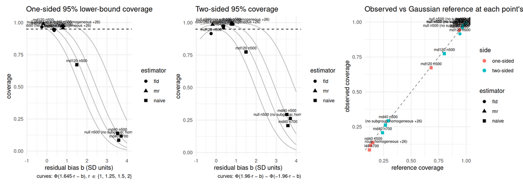

```r
DS$cell <- factor(DS$cell)
pH <- fs_plot_bias_coverage(DS[DS$block == "H", ], side = "lower")
ggsave(file.path(out_dir, sprintf("fig_%s_bias_coverage_display_H.png", tag)), pH, width = 13, height = 4.6, dpi = 130)   # as scripts_mdf1/stage3_aggregate.R:84
pH
```

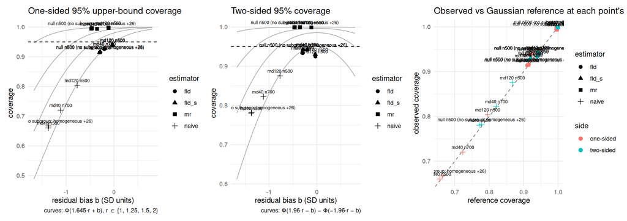

```r
pC <- fs_plot_bias_coverage(DS[DS$block == "Hc", ], side = "upper")
ggsave(file.path(out_dir, sprintf("fig_%s_bias_coverage_display_Hc.png", tag)), pC, width = 13, height = 4.6, dpi = 130)  # as scripts_mdf1/stage3_aggregate.R:85
pC
```

# 9 The extract

```r
X <- do.call(rbind, EX); X$value <- signif(X$value, 8); X$mc_se <- signif(X$mc_se, 6); X$wilson_lo <- signif(X$wilson_lo, 6); X$wilson_hi <- signif(X$wilson_hi, 6)
write.csv(X, file.path(out_dir, "md_field_metrics.csv"), row.names = FALSE, na = "")
cols <- c(
"# COLUMNS — md_field_metrics.csv (campaign mdsgnb20; TASK_md_field_rerun_2026-09-15 §3.2)", "",
"Written by `summary_continuous_field_mdsgnb20.qmd` from the same objects its tables print. One row per cell × block × estimator × metric (× tau for bound-location rows).", "",
"## Columns", "",
"- `campaign`: `mdsgnb20`, or `mdf1` for the paired comparator rows of the rule contrast (declaration rate, identification, field one-sided coverage on the same seeds).",
"- `cell`: `md40 n500`, `md120 n500`, `null n500 (no subgroup; homogeneous +26)`, `md40 n700`.",
"- `block`: `H` (the selected subgroup Ĥ), `Hc` (its complement Ĥᶜ), `joint` (the pair).",
"- `estimator`: see the code map below.",
"- `metric`: see the metric list below.",
"- `tau`: the D3 ladder threshold for bound-location rows (0, 10, 20, 30, 40, 60, 80, 100 on the harm-oriented MD scale); empty otherwise.",
"- `value`: the metric.",
"- `mc_se`: Monte Carlo standard error -- proportions sqrt(p(1-p)/n); bias SD/sqrt(n); empirical SD SD/sqrt(2(n-1)); mean SE SD(SE)/sqrt(n); SE/SD by the delta method (r * sqrt((mc_se(mean SE)/mean SE)^2 + (mc_se(SD)/SD)^2)); empty where none is defined (quantiles, display bookkeeping).",
"- `wilson_lo`, `wilson_hi`: Wilson 95% interval for proportions; empty otherwise.",
"- `n`: the denominator (declared replicates with the quantity defined; total replicates for the declaration rate).",
"- `commit`: the commit that added the cell's combined bundle.", "",
"## Estimator codes", "",
"- `naive`: the unadjusted plug-in estimate on the selected region (one-sided bound est -/+ 1.645 SE, robust SE).",
"- `oracle`: the refit on the true region Q / Q^c (its target is the structural effect; empty on Ĥ in the null cell).",
"- `mr`: MR (IJ two-term): the de-biased estimate with the infinitesimal-jackknife SE (one-sided bound est -/+ 1.645 SE_IJ).",
"- `fld`: MR (field): the shrunk-field estimate `est2` with the Λ*-quantile intervals; on Ĥ the one-sided lower bound `lo1s`; on Ĥᶜ the unstudentized complement field (`up1s`), shown as the paired before/after.",
"- `fld_s`: MR (field-s): the studentized complement field on Ĥᶜ (`est2_s`, `up1s_s`, `se_field_s`) -- the evaluated complement construction.",
"- `bonf_s` / `bonf` / `separate_s`: the field-s Bonferroni pair (gamma = 0.025 each side) / the unstudentized Bonferroni pair / the separate 95% pair (field lower on Ĥ, field-s upper on Ĥᶜ).",
"- `calibrated`: diagnostics of the calibrated joint split (mean gamma, corr(Λ*, Λ*ᶜ)), `_s` = studentized.",
"- `all`: cell-level quantities not tied to an estimator (declaration rate, identification, p-hat).", "",
"## Metrics", "",
"- `declaration_rate`: declared replicates / replicates.",
"- `bias_md`, `bias_sd_units`: mean(estimate - target), in MD units and divided by the empirical SD; the target is beta(Ĥ) / beta(Ĥᶜ) per replicate (the structural effect for the oracle).",
"- `sd_emp`, `se_mean`, `se_over_sd`: empirical SD of the estimate, mean reported SE, their ratio.",
"- `cov1_lower` (H) / `cov1_upper` (Hc): one-sided 95% coverage on the exposed side; `cov2`: two-sided 95% coverage.",
"- `halfwidth_md`, `margin1_md`: mean two-sided half-width; mean one-sided margin from beta-tilde (field rows) or from the estimate.",
"- `share_lower_ge_tau` (H): share of replicates whose one-sided lower bound is >= tau ('harm of at least tau supported'); `share_upper_le_tau` (Hc): share whose one-sided upper bound is <= tau ('harm of at most tau supported').",
"- `bound_mean`, `bound_q05` ... `bound_q95`: location of the one-sided bound.",
"- `joint_coverage`, `share_both_bounds`, `cov_H`, `cov_Hc`, `margin_H_md`, `margin_Hc_md`: joint pair rows on declared replicates carrying both bounds; margins in MD units from beta-tilde.",
"- `gamma_mean`, `corr`, `gamma_mean_s`, `corr_s`: calibrated-split diagnostics.",
"- `mean_n_harm`, `mean_n_sel`, `sensitivity_mean`, `ppv_mean`, `share_nharm_{grew,stayed,shrank}_vs_mdf1`, `count_nharm_{grew,stayed,shrank}_vs_mdf1`: identification, paired with mdf1 by sim_id (shares and counts of the paired replicates).",
"- `p_hat_mean`, `p_hat_share_lt_05`: re-selection frequency of the winner and the tie-regime share.",
"- `sd_btc_over_naive_se` (mr), `lamsd_over_naive_se` (fld, fld_s): regime diagnostics on Ĥᶜ.",
"- `display_b`, `display_r`, `display_cov1`, `display_cov1_ref`, `display_cov2`, `display_cov2_ref`: fs_sim_bias_coverage(scale = 'identity') bookkeeping.", "",
"## Scale convention", "",
"Every estimate, bound, bias and threshold is on the **harm-oriented mean-difference scale** (positive = harm; the gate works on -cd4_change because adverse_outcome = FALSE); `betaHhat_*` in the bundles are raw cd4_change and are oriented with -1 here. The null cell's truth is a homogeneous +26.255 on this scale for every Ĥ and Ĥᶜ. No significance language: bounds are read by location against the ladder.")
writeLines(cols, file.path(out_dir, "COLUMNS_md_field.md"))
cat(sprintf("extract: %d rows -> %s ; %s\n", nrow(X), file.path(out_dir, "md_field_metrics.csv"), file.path(out_dir, "COLUMNS_md_field.md")))
```

```
extract: 1114 rows -> ./md_field_metrics.csv ; ./COLUMNS_md_field.md
```